# SDS/CSC 293 Mini-Project 4: CART

Wednesday, April 17<sup>th</sup>, 2019

You will be fitting CART models to the data from the [Ghouls, Goblins, and Ghosts… Boo!](https://www.kaggle.com/c/ghouls-goblins-and-ghosts-boo/) Kaggle competition. The competition’s score for leaderboard purposes is the “Categorization Accuracy”. However you will **NOT** be making any submissions to Kaggle.

# Load data

Read in data provided by Kaggle for this competition. They are organized in the `data/` folder of this RStudio project:

```r
training <- read_csv("data/train.csv")
test <- read_csv("data/test.csv")
sample_submission <- read_csv("data/sample_submission.csv")
```

## Look at your data!

Always, ALWAYS, **ALWAYS** start by looking at your raw data. This gives you visual sense of what information you have to help build your predictive models. To get a full description of each variable, read the data dictionary in the `data_description.txt` file in the `data/` folder.

Note that the following code chunk has `eval = FALSE` meaning “don’t evaluate this chunk with knitting” because `.Rmd` files won’t knit if they include a `View()`:

```r
View(training)
glimpse(training)

View(test)
glimpse(test)
```

In particular, pay close attention to the variables and variable types in the `sample_submission.csv`. Your submission must match this exactly.

```r
glimpse(sample_submission)
```

```
## Observations: 529
## Variables: 2
## $ id   <dbl> 3, 6, 9, 10, 13, 14, 15, 16, 17, 18, 20, 21, 24, 26, 33, 38…
## $ type <chr> "Ghost", "Ghost", "Ghost", "Ghost", "Ghost", "Ghost", "Ghos…
```

# Minimally viable product

Perform the following exploratory data analyses:

## Univariate explorations

**Categorical predictor**: Create a visualization of the categorical predictor variable `color`.

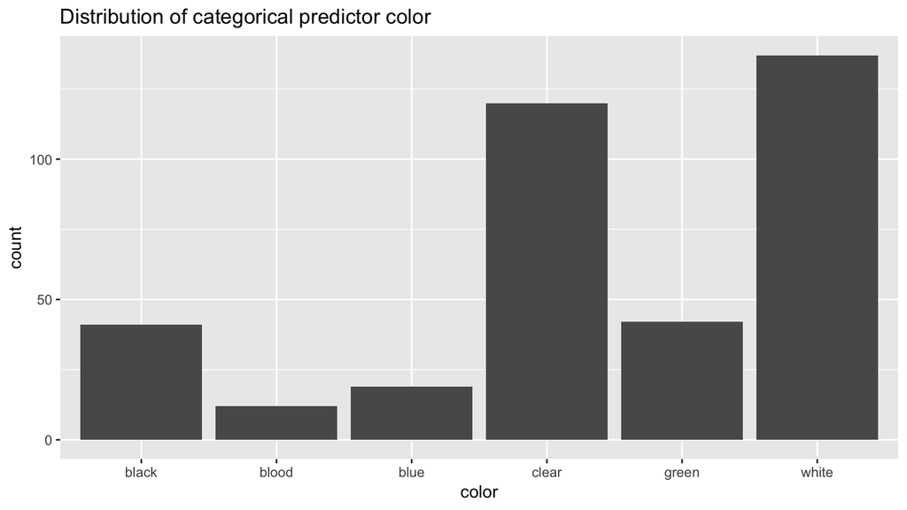

```r
ggplot(training, aes(x = color)) +
  geom_bar() +
  labs(x = "color", title = "Distribution of categorical predictor color")
```

**Outcome variable**: Create a visualization of the categorical predictor variable `type`.

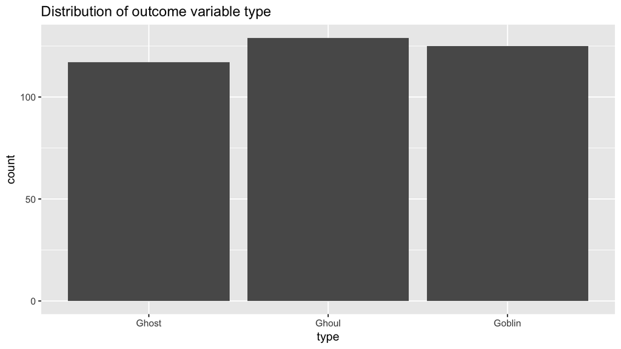

```r
ggplot(training, aes(x = type)) +
  geom_bar() +
  labs(x = "type", title = "Distribution of outcome variable type")
```

## Mutlivariate explorations

**Numerical predictors**: Create a visualization of the relationship of all four numerical predictor variables at once (`bone_length`, `rotting_flesh`, `hair_length`, `has_soul`) using the `ggpairs()` function from the `GGally` [package](http://ggobi.github.io/ggally/#ggallyggpairs).

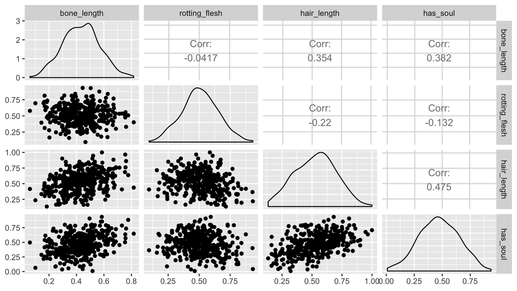

```r
training %>%
  select(bone_length, rotting_flesh, hair_length, has_soul) %>%
  ggpairs()
```

# Due diligence

1. Fit a CART where:
   - You use only the numerical predictors.
   - The maximum depth of the tree is 5.
   - You use the default “complexity parameter”
2. Plot the tree.
3. Make predictions `type_hat` on the `training` data. Hint compare the output of `predict(model_CART, type = "prob")` and `predict(model_CART, type = "class")`.
4. Compute the “classification accuracy”.

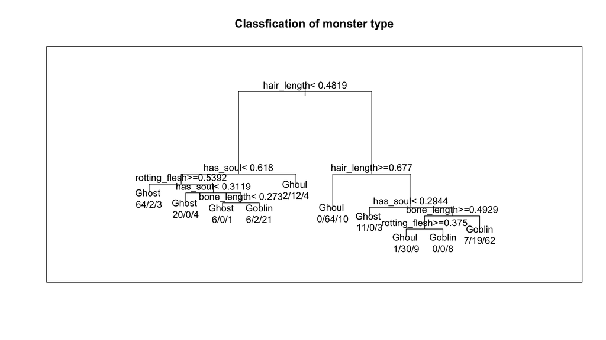

```r
# Fit CART model
model_formula <- as.formula(type ~ bone_length + rotting_flesh + hair_length + has_soul)
tree_parameters <- rpart.control(maxdepth = 5)
model_CART <- rpart(model_formula, data = training, control = tree_parameters)

# Plot tree
plot(model_CART, margin=0.25)
text(model_CART, use.n = TRUE)
title("Classfication of monster type")
box()
```

```r
# Fitted probabilities p_hat
p_hat_matrix_train <- model_CART %>%
  predict(type = "prob") %>%
  as_tibble()

# Show first 5 rows of p_hats
p_hat_matrix_train %>%
  slice(1:5)
```

| Ghost | Ghoul | Goblin |
| --- | --- | --- |
| 0.1111111 | 0.6666667 | 0.2222222 |
| 0.0250000 | 0.7500000 | 0.2250000 |
| 0.0000000 | 0.8648649 | 0.1351351 |
| 0.0250000 | 0.7500000 | 0.2250000 |
| 0.1111111 | 0.6666667 | 0.2222222 |

```r
# Predicted type_hat based on p_hat_matrix_train, with ties broken at random
training$type_hat <- predict(model_CART, type = "class")

# Show first 5 predicted class. See how they correspond to 5 rows of p_hats above
training$type_hat[1:5]
```

```
## [1] Ghoul Ghoul Ghoul Ghoul Ghoul
## Levels: Ghost Ghoul Goblin
```

```r
# Compute classification accuracy: proportion correct
training %>%
  dplyr::summarize(accuracy = mean(type == type_hat))
```

| accuracy |
| --- |
| 0.8032345 |

# Reaching for the stars

Note that the $\alpha$ complexity parameter is the `cp` argument to `rpart.control()`.

1. Reusing the MP1 solutions code, for the range of `alpha` complexity parameters in the `alpha_df` data frame, return an estimate of the accuracy/error that Kaggle would return.
2. Plot the relationship between the alpha complexity parameter and accuracy.
3. Using the optimal $\alpha^*$ complexity parameter, write a `submission.csv` suitable for submission to Kaggle.

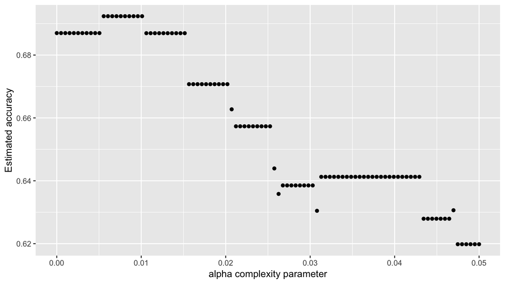

```r
alpha_df <- tibble(
  alpha = seq(from = 0, to = 0.05, length = 100),
  accuracy = 0
)

set.seed(76)
# Randomly assign folds only once i.e. outside of for loop
training <- training %>%
  sample_frac(1) %>%
  mutate(fold = rep(1:5, length = n())) %>%
  arrange(fold)

# For a search grid of alpha complexity parameters
for(i in 1:nrow(alpha_df)){
  alpha <- alpha_df$alpha[i]
  accuracy_per_fold <- rep(0, 5)

  # For all folds
  for(j in 1:5){
    # Set pretend training and pretend test that mimics the train vs test
    # relationship
    pretend_training <- training %>%
      filter(fold != j)
    pretend_test <- training %>%
      filter(fold == j)

    # Fit model on pretend training
    tree_parameters <- rpart.control(maxdepth = 5, cp = alpha)
    model_CART <- rpart(model_formula, data = pretend_training, control = tree_parameters)

    # Make predictions on pretend test and save
    pretend_test$type_hat <- predict(model_CART, newdata = pretend_test, type = "class")

    # Compute classification accuracy: proportion correct
    accuracy_per_fold[j] <- pretend_test %>%
      summarize(accuracy = mean(type == type_hat)) %>%
      pull(accuracy)
  }

  # Compute average accuracy across all 5 folds
  alpha_df$accuracy[i] <- mean(accuracy_per_fold)
}

# Plot the relationship between alpha complexity parameter and estimated
# accuracy
ggplot(alpha_df, aes(alpha, accuracy)) +
  geom_point() +
  labs(x = "alpha complexity parameter", y = "Estimated accuracy")
```

It appears for $\alpha$ complexity values of just under 0.01 we achieve the highest accuracy of around 69.2%. But which of the 10 $\alpha$ values should we use? It’s a rough principle that “all things being equal simpler models are to be preferred over complex ones” (this is called [Occam’s Razor](https://en.wikipedia.org/wiki/Occam%27s_razor)). Since larger $\alpha$ values penalize complexity more and hence yield simpler models, we should take the largest $\alpha$ that achieves a classification accuracy of 69.2%

```r
best_accuracy <- alpha_df %>%
  arrange(desc(accuracy), desc(alpha)) %>%
  slice(1)
best_accuracy
```

| alpha | accuracy |
| --- | --- |
| 0.010101 | 0.6923604 |

```r
alpha_star <- best_accuracy %>%
  pull(alpha)
```

Let’s now mark two $\alpha$ complexity parameters in Figure 1, which is the same plot as above but zoomed-in on the x-axis:

- The default $\alpha$ = `cp` = complexity parameter in `rpart.control()` of 0.01 (marked with vertical solid line)
- The optimal $\alpha^*$ we chose above (marked with vertical dashed line). Rather coincidentally, they are nearly the same value.

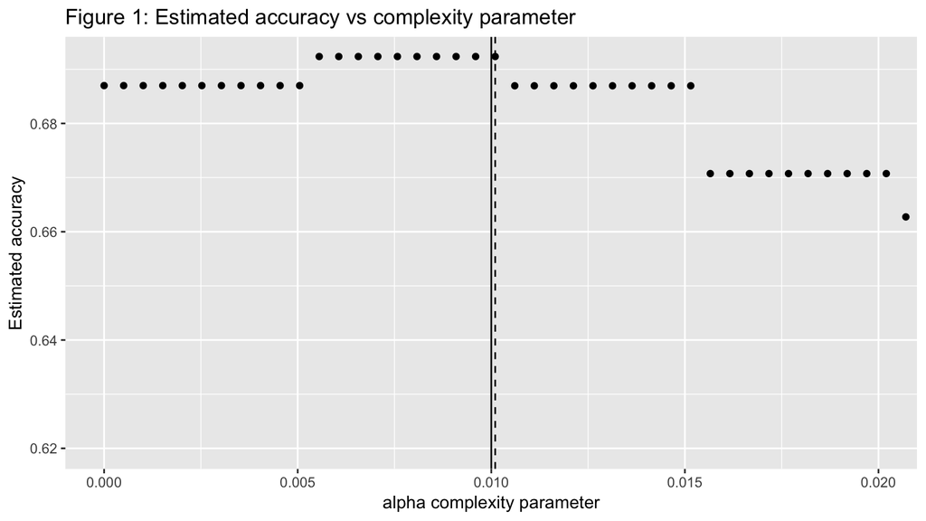

```r
# Plot the relationship between alpha complexity parameter and estimated
# accuracy
ggplot(alpha_df, aes(alpha, accuracy)) +
  geom_point() +
  labs(x = "alpha complexity parameter", y = "Estimated accuracy", title = "Figure 1: Estimated accuracy vs complexity parameter") +
  geom_vline(xintercept = alpha_star, linetype = "dashed") +
  geom_vline(xintercept = 0.01) +
  coord_cartesian(xlim = c(0, 0.02))
```

Note how the vertical solid line corresponding to the default $\alpha$ = 0.01 indicates a classification accuracy of 69.2%. Compare this to the 80.3% you computed earlier.

Let’s now use this $\alpha^*$ to fit a CART on all the `training` data, make predictions on `test`, and create a `submisssion.csv` suitable for submission to Kaggle.

```r
tree_parameters <- rpart.control(maxdepth = 5, cp = alpha_star)
model_CART <- rpart(model_formula, data = training, control = tree_parameters)
test$type_hat <- predict(model_CART, newdata = test, type = "class")

test %>%
  select(id, type = type_hat) %>%
  write_csv("data/submisssion.csv")
```

# Point of diminishing returns

- Use one-hot-enconding to fit a predictive CART model using the categorical variable `color` and plot the tree. Set the maximum depth of the tree to 5 and use the default “complexity parameter”.
- No need to generate an estimate of the accuracy that Kaggle would return.

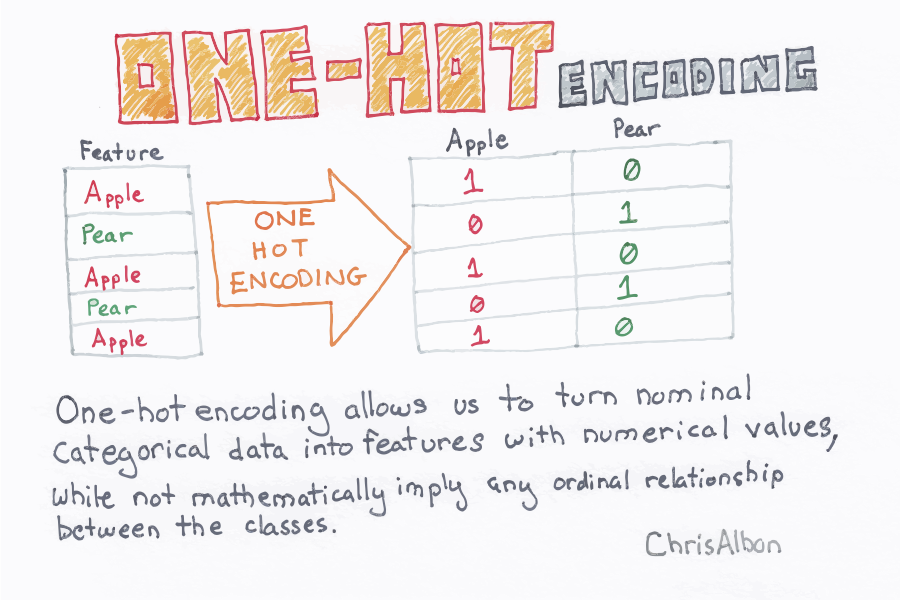

Why are we using one-hot-encoding? Because binary splits can only occur on a numerical variable. Since our one-hot-encoded variables are 0 if `FALSE` and 1 if `TRUE`, the splits occur on whether or not the monster is of a certain color.

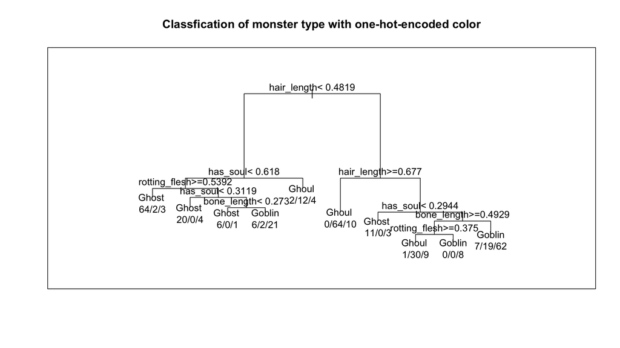

```r
training <- training %>%
  mutate(
    black = as.numeric(color == "black"),
    blood = as.numeric(color == "blood"),
    blue = as.numeric(color == "blue"),
    clear = as.numeric(color == "clear"),
    green = as.numeric(color == "green"),
    white = as.numeric(color == "white")
  )

# Fit CART model
model_formula <- as.formula(
  type ~ bone_length + rotting_flesh + hair_length + has_soul +
    black + blood + blue + clear + green + white
)
tree_parameters <- rpart.control(maxdepth = 5)
model_CART <- rpart(model_formula, data = training, control = tree_parameters)

# Plot tree
plot(model_CART, margin=0.25)
text(model_CART, use.n = TRUE)
title("Classfication of monster type with one-hot-encoded color")
box()
```

Interesting. It seems even though we added our one-hot-encoded variables `black`, `blood`, `blue`, `clear`, `green`, and `white` to our model formula, we see no splits involving these `color` variables.

Just for fun, let’s fit a CART using only the color variables, using the default `cp` complexity parameter of 0.01 in Figure 2:

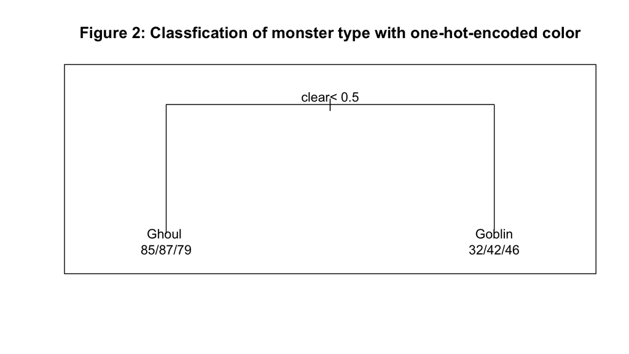

```r
# Fit CART model
model_formula <- as.formula(type ~ black + blood + blue + clear + green + white)
tree_parameters <- rpart.control(maxdepth = 5)
model_CART <- rpart(model_formula, data = training, control = tree_parameters)

# Plot tree
plot(model_CART, margin=0.25)
text(model_CART, use.n = TRUE)
title("Figure 2: Classfication of monster type with one-hot-encoded color")
box()
```

Now let’s set a different `cp` complexity parameter in the `rpart.control()`: a value of 0. In other words, complexity is not penalized at all! Your tree can grow as much as it wants! (subject to the other restrictions in `rpart.control()`)

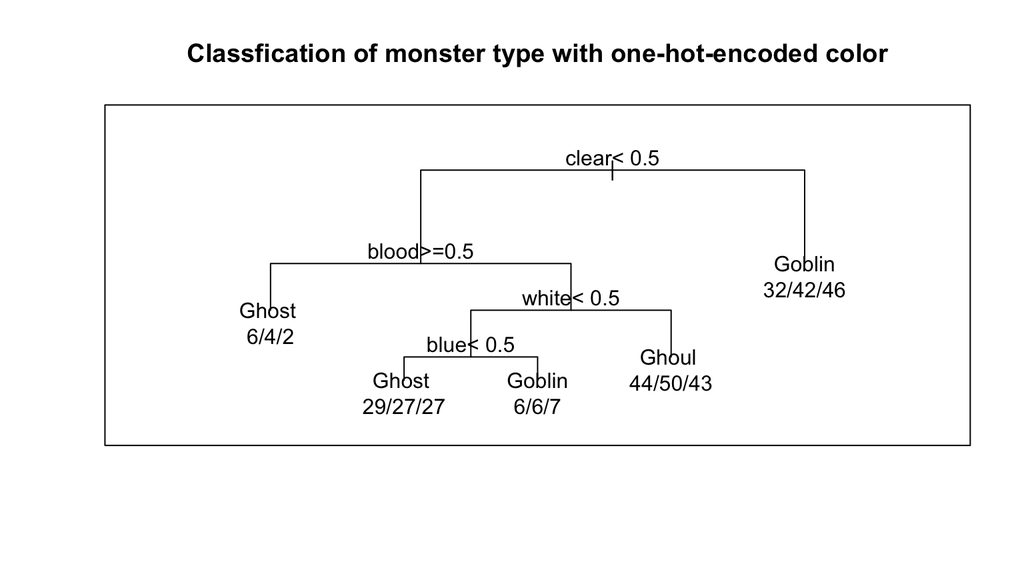

```r
# Fit different CART model
model_formula <- as.formula(type ~ black + blood + blue + clear + green + white)
tree_parameters <- rpart.control(maxdepth = 5, cp = 0)
model_CART <- rpart(model_formula, data = training, control = tree_parameters)

# Plot different tree
plot(model_CART, margin=0.25)
text(model_CART, use.n = TRUE)
title("Classfication of monster type with one-hot-encoded color")
box()
```

# Polishing the cannonball

None